# Midterm Project Part Two

Madeline Greene

## Load Data

```r
## Read in and save your two tidy CSV files here for downstream use.
## Show their output with head() for reproduciblity!
read_csv("treatment_results.csv") -> treatment_results
head(treatment_results)
```

```
## # A tibble: 6 x 19
##   plot  treatment Algal_Total Algal_Species Id    morph growth growthBin  dead
##   <chr> <chr>           <dbl>         <dbl> <chr> <chr>  <dbl>     <dbl> <dbl>
## 1 1C    Control            50            15 DS1 … moun… -0.285        -3     0
## 2 1C    Control            50            15 DS1 … moun… -0.285        -3     0
## 3 1C    Control            50            15 DS1 … moun… -0.285        -3     0
## 4 1C    Control            50            15 DS1 … moun… -0.285        -3     0
## 5 1C    Control            50            15 DS1 … moun… -0.285        -3     0
## 6 1C    Control            50            15 DS1 … moun… -0.285        -3     0
## # … with 10 more variables: algalContact <dbl>, avgContact <dbl>, max <dbl>,
## #   Month <chr>, Year <dbl>, Species <chr>, Percent_cover <dbl>, tile <dbl>,
## #   recruits <dbl>, algaeBiomass_mg <dbl>
```

```r
read_csv("plot_bites.csv") -> plot_bites
head(plot_bites)
```

```
## # A tibble: 6 x 7
##   treatment family      sizeBin Month     Year timeCorrBites timeCorrBiomassBit…
##   <chr>     <chr>       <chr>   <chr>    <dbl>         <dbl>               <dbl>
## 1 Control   Acanthurid… 12.5    Septemb…  2013           159               9495.
## 2 External  Acanthurid… 12.5    Septemb…  2013           151              10444.
## 3 Full      Acanthurid… 12.5    Septemb…  2013             0                  0
## 4 Partial   Acanthurid… 12.5    Septemb…  2013           357              26199.
## 5 Control   Scaridae    12.5    Septemb…  2013            20                556.
## 6 External  Scaridae    12.5    Septemb…  2013            25               1277.
```

## Figure 3B

```r
## Code to prepare data for plotting goes here.
## It should save a dataset you can use to plot in the next chunk.
plot_bites %>%
  filter(family == c("Acanthuridae", "Scaridae"), treatment == c("Full", "Partial", "Control")) %>%
  #only need the two families according to previos graph and then filtered all treatment types
  mutate(bites_corr_hour = (timeCorrBites/60))%>%
  select(treatment,family, bites_corr_hour) -> new_bites_hour
  #out of all the columns, only needed treatment, family, and timeCorrBites

head(new_bites_hour)
```

```
## # A tibble: 6 x 3
##   treatment family       bites_corr_hour
##   <chr>     <chr>                  <dbl>
## 1 Partial   Acanthuridae           0
## 2 Control   Scaridae               0.05
## 3 Partial   Scaridae               0.133
## 4 Control   Acanthuridae           0
## 5 Full      Acanthuridae           0
## 6 Partial   Scaridae               0
```

```r
#making sure it has all necessary components for graph
```

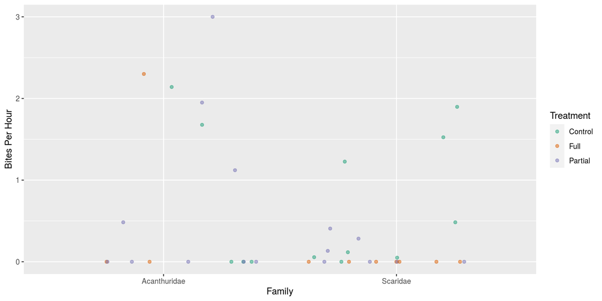

```r
## plot the data here.
## ensure an appropriate figure size and legible output by setting the fig.width and fig.height for this chunk
new_bites_hour %>%
  ggplot(aes(x = family, y= bites_corr_hour)) +
  geom_jitter(aes(color=treatment), alpha=0.5)+ #used alpha so can guarantee seeing all of the points
  scale_color_brewer(palette= "Dark2") + #colorblind friendly palette
  labs(x = "Family", y = "Bites Per Hour", color = "Treatment") ->figure3b


figure3b
```

The data here was very hard to interpret from the figure they provided us with. I believe that the metadata sheet and the figures did not correspond correctly with each other. When viewing the data, it appears that both families had a lot of the same results of 0 bites per minute. Because I am not knowledgeable about this specific data, I cannot tell if that is normal or an error of results. I changed it to per hour as the axis title which makes the data more understandable. I believe that a jitter plot was appropriate to display this data because it was able to show compare both families and provide exact points of the recorded data.

## Figure 5B

```r
## Code to prepare data for plotting goes here.
## It should save a dataset you can use to plot in the next chunk.

treatment_results %>%
  filter(Species == "artCal") %>%
  #only selecting articulated calcareous algae
  select(Species, treatment, Month, Year, Percent_cover) -> new_artcal_results
  #figure will need the species, month/year, percent cover

head(new_artcal_results)
```

```
## # A tibble: 6 x 5
##   Species treatment Month      Year Percent_cover
##   <chr>   <chr>     <chr>     <dbl>         <dbl>
## 1 artCal  Control   July       2013             9
## 2 artCal  Control   July       2013             9
## 3 artCal  Control   July       2013             9
## 4 artCal  Control   July       2013             9
## 5 artCal  Control   September  2013            12
## 6 artCal  Control   September  2013            12
```

```r
#making sure it has all necessary components for figure
```

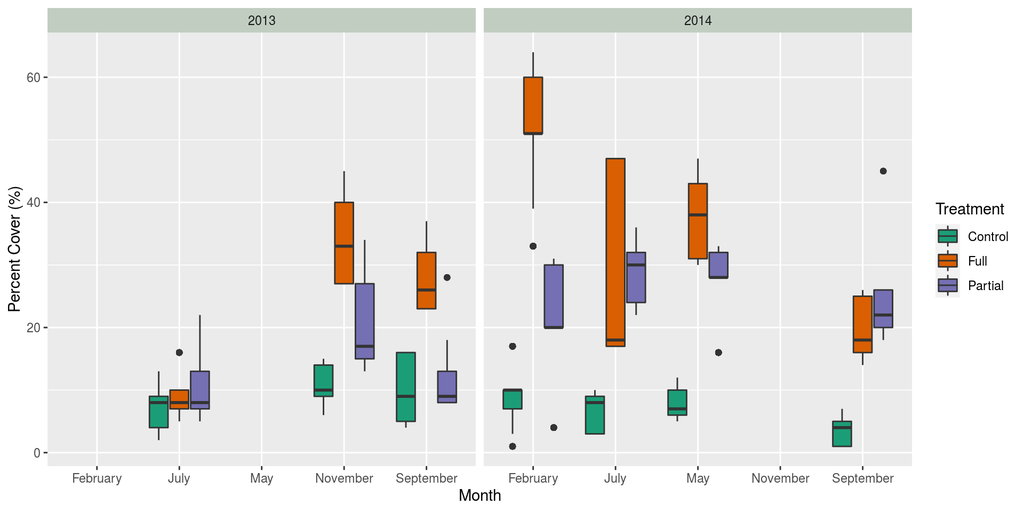

```r
## plot the data here.
## ensure an appropriate figure size and legible output by setting the fig.width and fig.height for this chunk

new_artcal_results %>%
  ggplot(aes(x = Month, y = Percent_cover, fill= treatment)) +
  geom_boxplot(position = position_dodge2(width = 1)) +
  #would be able to show outliers in this form of graph as well as average
  facet_grid(~Year)+
  #wanted the years next to eachother to observe year difference
  scale_fill_brewer(palette= "Dark2") +
  #colorblind friendly palette
  theme(strip.background = element_rect(fill = "honeydew3")) +
  #felt like switching up the header color
  labs(y = "Percent Cover (%)", fill = "Treatment") -> figure_5b

figure_5b
```

## Figure 6A

```r
## Code to prepare data for plotting goes here.
## It should save a dataset you can use to plot in the next chunk.

treatment_results %>%
 mutate(Morph = case_when(morph == "mound.crust" ~ "Mounding & Encrusting Corals", morph == "branch" ~ "Branching Corals")) %>%
  drop_na(Morph) %>%
  #removed NAs
  select(- morph) %>%
  #removed column since created a new one with new names
  mutate(growth = growth * 100) %>%
  #after looking at data again and graph, realized that it was not in percent so needed to multiply by 100
  select(Morph, growth, treatment) -> new_morph
  #only shows what I will be graphing so it is cleaner to look like and when deciding how to wrangle data

new_morph
```

```
## # A tibble: 37,632 x 3
##    Morph                        growth treatment
##    <chr>                         <dbl> <chr>
##  1 Mounding & Encrusting Corals  -28.5 Control
##  2 Mounding & Encrusting Corals  -28.5 Control
##  3 Mounding & Encrusting Corals  -28.5 Control
##  4 Mounding & Encrusting Corals  -28.5 Control
##  5 Mounding & Encrusting Corals  -28.5 Control
##  6 Mounding & Encrusting Corals  -28.5 Control
##  7 Mounding & Encrusting Corals  -28.5 Control
##  8 Mounding & Encrusting Corals  -28.5 Control
##  9 Mounding & Encrusting Corals  -28.5 Control
## 10 Mounding & Encrusting Corals  -28.5 Control
## # … with 37,622 more rows
```

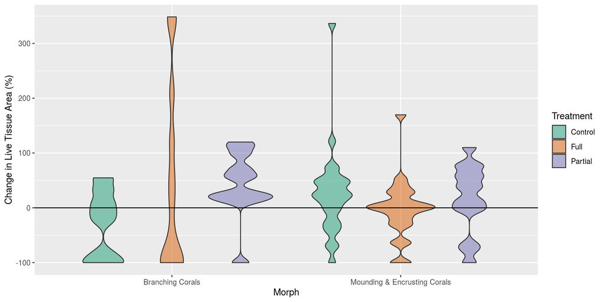

```r
## plot the data here.
## ensure an appropriate figure size and legible output by setting the fig.width and fig.height for this chunk

new_morph %>%
  ggplot(aes(x = Morph, y = growth, fill = treatment)) +
  geom_violin(alpha = 0.5) +
  #would show distribution of data/be able to properly see black line
  scale_fill_brewer(palette = "Dark2") +
  #colorblind friendly
  labs(y = "Change in Live Tissue Area (%)", fill = "Treatment") +
  geom_hline(yintercept = 0, col = "black")  -> figure_6a
  #had a black line go through the y intercept to show where there is 0 % change

figure_6a
```

This figure is significantly different from the figure provided in the paper. It provides more information than just the average with a standard deviation line. I used a violin plot to show the distribution of where there were changes in live tissue. I did in fact change my original wrangled data after initially plotting. When I first plotted, I noticed that the y values were -1 to 3. This would not make sense based on the data or representing a percent change. Therefore, I re-wrangled my data to make it a percent by multiplying by 100. The data looks different, probably because it is not an average and rather a distribution. In the original figure, it ranged from -100 to 100 but in this new figure, it ranges from -100 to 300. This is showing that it is true that their way of measuring means that is greater than 100% is possible due to multiple layers of covers.

## Figure 6B

```r
## Code to prepare data for plotting goes here.
## It should save a dataset you can use to plot in the next chunk.

treatment_results %>%
  filter(Species == "totalAlgae") %>%
  #only plotting Algae totals
   mutate(Morph = case_when(morph == "mound.crust" ~ "Mounding & Encrusting Corals", morph == "branch" ~ "Branching Corals")) %>%
  drop_na(Morph) %>%
  #removed NAs
  select(- morph) %>%
  #removed column since created a new one with new names
  mutate(growth = growth * 100) %>%
  #made it a percent not decimal
  select(Morph, treatment, growth, Percent_cover) -> new_algal_cover
  #selected only columns that were needed

new_algal_cover
```

```
## # A tibble: 2,688 x 4
##    Morph                        treatment growth Percent_cover
##    <chr>                        <chr>      <dbl>         <dbl>
##  1 Mounding & Encrusting Corals Control    -28.5            98
##  2 Mounding & Encrusting Corals Control    -28.5            98
##  3 Mounding & Encrusting Corals Control    -28.5            98
##  4 Mounding & Encrusting Corals Control    -28.5            98
##  5 Mounding & Encrusting Corals Control    -28.5            81
##  6 Mounding & Encrusting Corals Control    -28.5            81
##  7 Mounding & Encrusting Corals Control    -28.5            81
##  8 Mounding & Encrusting Corals Control    -28.5            81
##  9 Mounding & Encrusting Corals Control    -28.5            84
## 10 Mounding & Encrusting Corals Control    -28.5            84
## # … with 2,678 more rows
```

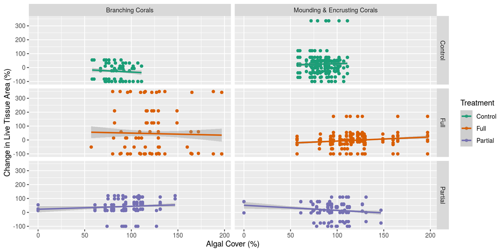

```r
## plot the data here.
## ensure an appropriate figure size and legible output by setting the fig.width and fig.height for this chunk

new_algal_cover %>%
  ggplot(aes(x = Percent_cover, y = growth, color = treatment)) +
  geom_point()+
  #scatterplot to show where data points are
  facet_grid(treatment~ Morph) +
  #wanted to separate morphs and treatments to better understand data
  scale_color_brewer(palette = "Dark2") +
  #colorblind friendly color
  labs(y = "Change in Live Tissue Area (%)", x = "Algal Cover (%)", color = "Treatment") +
  geom_smooth(method = "lm") -> figure_6b
  #made smooth trendlines

figure_6b
```